# Workshops

**Note**

Please add your comments on this section in [this Google Doc](https://docs.google.com/document/d/1PAcGNN8I-uhIurImGTq_f-M5wQ7yeE7Rv7JEik2atjg/edit?usp=sharing).

To develop this online guidance on the use of climate data in the energy sector, a series of workshops were conducted with Canadian energy organizations. These workshops aimed to gain deeper insight into how climate information is applied in real-world decision-making. The insights gathered are integrated throughout the guidance, with illustrative examples of applications provided across various energy sector activities.

### Goals

- Better understand how climate information is used in the Canadian electrical industry
- Identify missing information (ex: climate variables or tools) in the decision-making process that relies on climate information
- Funnel approach: starting with describing a decision-making challenge and moving toward more technical (ex: temporal and spatial scales of the datasets used)

### Overview of the workshops section

- **Content and participation**  
  Present the content of the workshops as well as participation by organization and sector
- **Findings**  
  General findings of the workshops such as flow of climate information in organziation and what’s missing for climate data usage in practice

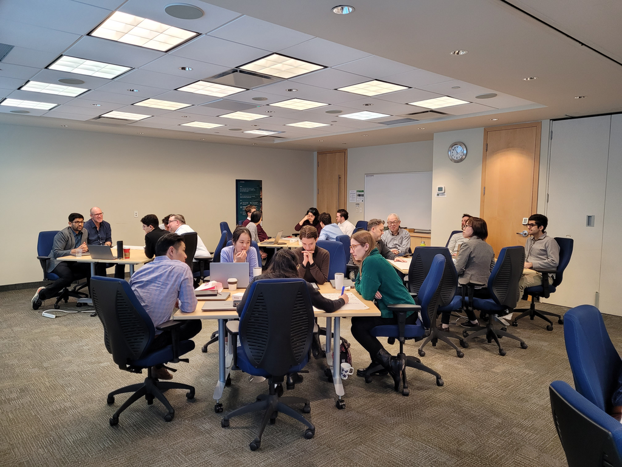